# Rapport Analytique des Cours Boursiers

AAPL & GOOGL - Analyse Intraday

Système Automatisé HedgeFound

02 July 2025 à 01:11

## Analyse des Cours Boursiers AAPL et GOOGL

### Contexte de Marché

Les données présentées ci-dessous représentent une analyse intraday des actions Apple (AAPL) et Alphabet (GOOGL), deux des composantes majeures du NASDAQ-100. Cette analyse s’inscrit dans le cadre de notre phase de test du système automatisé HedgeFound, visant à identifier des opportunités de trading à haute fréquence.

Dernière mise à jour: 02 July 2025 à 01:11:41

[figure not shown]

### Indicateurs Clés

Résumé des indicateurs clés

| Symbole | Minimum | Maximum | Dernier | Volatilité | Variation (%) |
| --- | --- | --- | --- | --- | --- |
| AAPL | 207.04 | 209.91 | 207.86 | 0.63 | 0.40 |
| GOOGL | 173.58 | 175.87 | 175.87 | 0.52 | 0.33 |

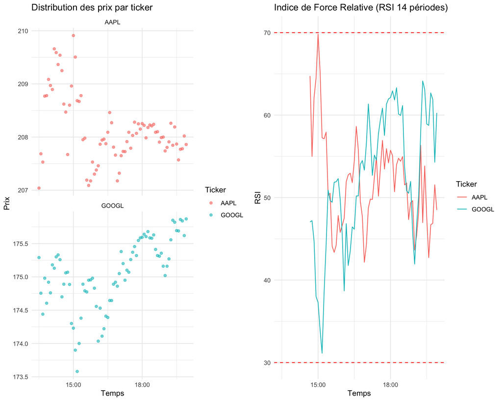

### Analyse Technique

1. **Tendances** : La moyenne mobile simple (5 périodes) montre la direction court-terme
2. **Momentum** : Le RSI (14 périodes) indique les conditions de surachat (>70) ou de survente (<30)
3. **Volatilité** : L’écart-type des prix donne une mesure de l’instabilité du marché

### Recommandations de Test

Dans le cadre de cette phase de test, nous suggérons de : - Surveiller les croisements de prix avec la moyenne mobile - Tester des stratégies de mean-reversion lorsque le RSI sort des zones extrêmes - Valider les paramètres de gestion du risque avec ces données historiques

```
## Les données de volume ne sont pas disponibles dans ce jeu de données.
```

### Perspectives

Cette analyse préliminaire servira de base pour les développements futurs du système HedgeFound. Les prochaines itérations incluront : - Des indicateurs techniques supplémentaires (MACD, Bollinger Bands) - Une analyse des corrélations entre actifs - Des tests de stratégies automatisées